# 70-467 Machine Learning for Business Analytics

Linear Regression

Professor: Andrés Castaño Zuluaga

26 and 31 August 2026 · CMU-Q

[figure not shown]

[figure not shown]

## Outline

1. What a regression is for: descriptive vs explanatory vs predictive
2. Simple regression: estimation, interpretation and goodness of fit
3. Statistical vs economic significance: Is the slope large enough to matter?
4. Multiple regression and nested models
5. Interpreting categorical variables
6. Interactions + extensions + potential problems (ISLR pp. 87–103)

## Uses of regression

## Four uses of regression

Descriptive

### How do the variables relate to each other?

the scatter plot of Sales against Price

Explanatory

### How's Y associated with X?

β: change in Y per unit of X, while keeping other variables constant

Causal

### If we change X, what happens to Y?

Compare sales in stores that cut prices (treatment) vs those who did not

Condition: Only if X is randomized, or as-if random (natural experiment).

Predictive

### What sales do we guess for a store with a given set of features?

Estimare the value of sales given values of the features E(Ŷ | X)

## Why we estimate $f$?

- A quantitative response is

$$Y = f(X) + \varepsilon.$$

- $f$ is unknown. $\varepsilon$ is leftover, mean zero, independent of $X$.
- Why estimate $f$?
  - **Prediction.** Produce $\hat Y = \hat f(X)$ for a new store or next quarter.
  - **Inference.**
    - Determine how $Y$ is connected to $X$. That is **explanation**.
    - If $X$ is randomized, or as-if random, the same $\hat f$ can be read as **causation**: what happens if we change $X$.
- Linear regression restricts $f$ to a linear form (or a plane). That restriction is what makes $\hat\beta$ easier to interpret. Why?

## $Y$ as continuous vs discrete variable

- **Regression:** $Y$ is quantitative (continuous variable). Here, unit sales.
- **Classification:** $Y$ is a category. $Y=1$ if a stock return in a given day was positive.
  - Later in the term (logistic regression).
- A linear model for a quantitative $Y$ is

$$f(X) = \beta_0 + \beta_1 X_1 + \cdots + \beta_p X_p.$$

- Simple linear regression is the case $p = 1$. Multiple linear regression is $p > 1$. The error term is still there:

$$Y = \beta_0 + \beta_1 X_1 + \cdots + \beta_p X_p + \varepsilon.$$

## The population simple regression

- With one predictor. The **population** regression line is

$$Y = \beta_0 + \beta_1 X + \varepsilon.$$

- $\beta_0$: intercept → $\mathrm{E}(Y \mid X = 0)$
- $\beta_1$: slope → average change in $Y$ associated with a one-unit change in $X$
- $\varepsilon$: everything not include (other variables, measurement error, nonlinearity)
- We do not observe $\beta_0$ and $\beta_1$. We observe $n$ pairs $(x_i, y_i)$ and compute estimates $\hat\beta_0$, $\hat\beta_1$. The **estimate** line is

$$\hat y_i = \hat\beta_0 + \hat\beta_1 x_i, \qquad e_i = y_i - \hat y_i.$$

- $e_i$ is the $i$th **residual**.

## Data: 400 stores, one product

- A firm sells the **same** child car seat through **400 stores**. The seat is the same. The store is not.
- In some locations the seat sits at eye level. In others it is on a bad shelf, next to a cheaper rival.
- Headquarters is exploring three things for next quarter: **list price**, **local advertising**, and **shelf quality**. They also have to live with a competitor who already posted a price, and with neighborhoods that differ in income and other characteristics.
- **Outcome $Y$:** `Sales` → unit sales, in thousands.
- **We start with:** `Price` → list price, in dollars.

## Variables used in the models

| Variable | Definition |
| --- | --- |
| Sales | Unit sales (thousands) |
| Price | Own list price (dollars) |
| CompPrice | Competitor’s price (dollars) |
| Advertising | Local advertising budget (thousands of dollars) |
| ShelveLoc | Shelf quality: Bad, Medium, Good |
| Income | Community income (thousands of dollars) |
| Also in the file |  |
| Population, Age, Education, Urban, US | Neighborhood and location indicators |

## Questions the linear model can answer

- What types of questions can a linear model answer with this data?
1. Is price associated with sales? descriptive
2. How strong is that association? descriptive / explanatory
3. How large is each association, in units of sales? explanatory
4. How accurately can we guess sales for a store with given $X$? predictive
5. Is a straight line reasonable? descriptive
6. Do predictors interact (synergy)? later
7. Do we have any causal questions that we can answer with this dataset? If not, what would be required to answer them? later

## Simple linear regression

## Motivating the relationship: Sales against Price

- $n = 400$. Negative association is visible.

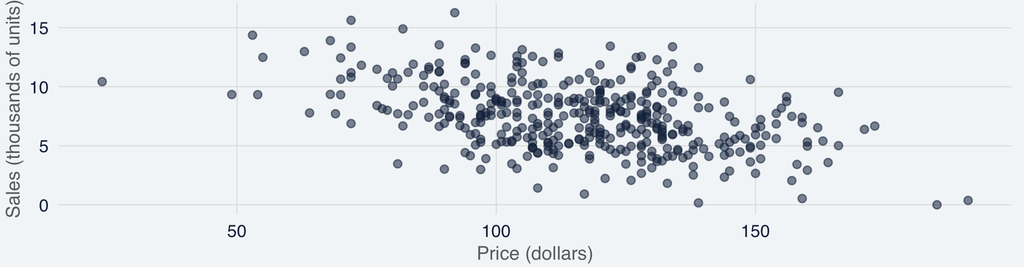

## How to choose the best line? → Least squares

- Choose $\hat\beta_0$ and $\hat\beta_1$ to minimize the **residual sum of squares**

$$\mathrm{RSS} = \sum_{i=1}^{n} (y_i - \hat\beta_0 - \hat\beta_1 x_i)^2 = \sum_{i=1}^{n} e_i^2.$$
- What do you think is the intuition behind this idea?

## Fitted line: Sales on Price

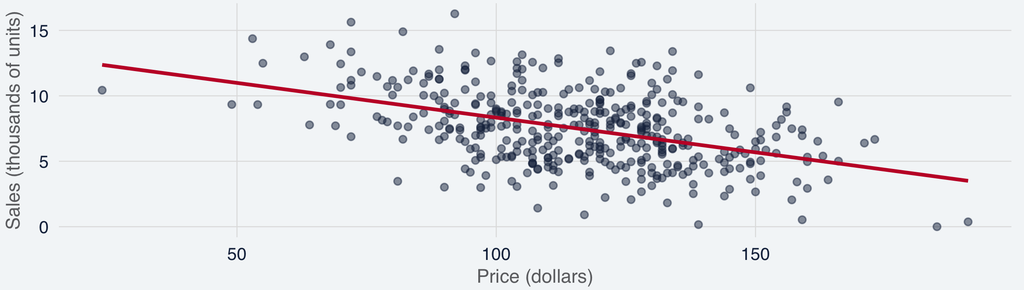

## Least squares in R: `lm(Sales ~ Price)`

```r
m1 <- lm(Sales ~ Price, data = stores)
coef(m1)
```

```
(Intercept)       Price
13.64191518 -0.05307302
```

- `Sales ~ Price` is the model formula: Sales as a function of Price, plus an intercept.
- RSS = 2,552.2. What do you think is this number trying to convey?
- $n - 2 = 398$ residual degrees of freedom.

## Coefficient table: estimate, SE, $t$, $p$

| Term | Estimate | Std. Error | t | p-value |
| --- | --- | --- | --- | --- |
| (Intercept) | 13.6419 | 0.6328 | 21.56 | < 0.001 |
| Price | -0.0531 | 0.0054 | -9.91 | < 0.001 |

- **Estimate.** $\hat\beta$.
- **Std. Error.** Estimated standard deviation of $\hat\beta$ across samples of this size.
- **$t$.** $\hat\beta / \mathrm{SE}(\hat\beta)$. How many standard errors $\hat\beta$ is from zero.
- **$p$-value.** Probability, under $H_0{:}\ \beta = 0$, of a $|t|$ at least this large.

## What $\hat\beta_0$ and $\hat\beta_1$ mean?

| Coefficient | Estimate | Meaning in this file |
| --- | --- | --- |
| Intercept $\hat\beta_0$ | 13.64 | Estimated sales if Price $= 0$. Business relevance? |
| Price $\hat\beta_1$ | -0.053 | A one-dollar higher price is associated with -0.053 thousand fewer units, about 53 seats. Business relevance? |

- That is an association in 400 observed stores. It is not the effect of an experimental price reduction.
- Under what conditions could $\hat\beta_1$ be a causal effect? Why?

If list price were assigned at random ( or as-if random) across stores, $\hat\beta_1$ would be the effect of a one-dollar higher price. In this dataset, stores chose their own prices. So $\hat\beta_1$ is an association, not the causal effect of a price reduction.

## Statistical significance versus economic significance

| Term | Estimate | Std. Error | t | p-value |
| --- | --- | --- | --- | --- |
| (Intercept) | 13.6419 | 0.6328 | 21.56 | < 0.001 |
| Price | -0.0531 | 0.0054 | -9.91 | < 0.001 |

- We already know the Price coefficient is statistically significant. Does it have economic content that would matter for a decision? How would you tell?

## Three potential approcahes for whether a coefficient is large

- The firm ask you the question: is a $10 price increase large enough to matter?
- Economists look at **size in the units of the decision**, not at p-values. Three comparisons on this file:
  - Turn $10 into seats: $10 \times \hat\beta_1$.
  - Compare that to **mean sales** (is it a big reduction for a typical store?).
  - Use **mean sales** with the **SD of sales** to determine what a price change would be in terms of moving a given store a lot relative to the average store.
  - Compare that to the **residual standard error** (is it big next to what I can’t explain?).

## Size effect of a $10 price increase

- $10 $\times$ slope $\approx$ -0.53 thousand units, about 531 seats.
- Mean sales $= 7.50$. That $10 price increase is about 7% of typical sales.
  - Another way to gauge this effect is to determine how big is the effect by also using the **SD of sales**, think for instance on whether an effect would be big if a one unit change move a store from being in the mean of sales, to the 35th percentile?
- RSE $= 2.53$. A typical miss is larger than the effect of a $10 price increase.
- **So: does $\hat\beta_1$ have economic content that is relevant for decisions? Why?**

Precise slope. A $10 price increase is about 7% of typical sales, but smaller than a typical miss.

## Accuracy of the slope and of the fit

Standard errors, confidence intervals, RSE, $R^2$.

## Standard error of $\hat\beta_1$ and a 95% interval

- If the errors are uncorrelated with constant variance $\sigma^2$,

$$\mathrm{SE}(\hat\beta_1)^2 = \frac{\sigma^2}{\sum_{i=1}^{n}(x_i - \bar x)^2}.$$

- $\sigma$ is unknown. We estimate it from the residuals (next slide). For Price,

$$\mathrm{SE}(\hat\beta_1) = 0.0054.$$

- An approximate 95% confidence interval is $\hat\beta_1 \pm 2\,\mathrm{SE}(\hat\beta_1)$:

$$[-0.064,\
-0.042].$$

- The interval does not contain zero. That is the same information as the $t$ of -9.9 on the previous table.

In business terms: about 53 seats per extra dollar of list price . Still an association in these 400 stores.

## Test: is the Price slope zero?

$$H_0{:}\ \beta_1 = 0 \quad\text{versus}\quad H_a{:}\ \beta_1 \neq 0.$$

- Under $H_0$, there is no linear association between Price and Sales. The test statistic is

$$t = \frac{\hat\beta_1 - 0}{\mathrm{SE}(\hat\beta_1)} = -9.91.$$

- The $p$-value is $< 0.001$. We reject $H_0$.

A small $p$-value is not a recommendation to cut the price. Why?

## Residual standard error: leftover in units of sales

- Even if $\beta_0$ and $\beta_1$ were known, $\varepsilon$ would remain. The **residual standard error** estimates $\sigma$:

$$\mathrm{RSE} = \sqrt{\frac{1}{n-2}\sum_{i=1}^{n} e_i^2} = \sqrt{\frac{\mathrm{RSS}}{n-2}}.$$

- For this fit, RSE $= 2.53$ thousand units. Typical deviation of actual sales from the estimated line, in the units of $Y$.
- RMSE $= \sqrt{n^{-1}\sum e_i^2}$ divides by $n$ instead of $n-2$.
- Mean sales in the file: 7.50 thousand.
  - RSE is about 34% of that mean.
- **Problem with RSE as a measure of how good the fitted line is?**

## $R^2$: share of variance associated with the line

- RSE is scale-dependent. $R^2$ is the fraction of variance in $Y$ explained by the model:

$$TSS = ESS + RSS \\
\sum_{i=1}^{n}(y_i - \bar y)^2 = \sum_{i=1}^{n}(\hat y_i - \bar y)^2 + \sum_{i=1}^{n}(y_i - \hat y_i)^2$$
$$R^2 = 1 - \frac{\mathrm{RSS}}{\mathrm{TSS}}$$

- TSS is the RSS of the intercept-only model (predict $\bar y$ for every store).
- For Sales on Price, $R^2 = 0.198$. About one fifth of the variation in sales is explained by the variation in prices.
- In applications of this kind, $R^2$ well below 1 is typical.
  - However is $R^2 = 0.20$ good enough given the context?

## Multiple linear regression

## Why Price alone is not enough?

- Price and CompPrice move together.
- What’s the problem with no including CompPrice in the regression?
- **Multiple linear regression** includes several predictors at once. The coefficient on Price is then the association with Sales **holding the other included predictors fixed**.

## The multiple regression equation

$$Y = \beta_0 + \beta_1 X_1 + \cdots + \beta_p X_p + \varepsilon,$$

or, equivalently,

$$\mathrm{E}(Y \mid X_1,\ldots,X_p) = \beta_0 + \beta_1 X_1 + \cdots + \beta_p X_p.$$

- $\beta_j$ is the average change in $Y$ associated with a one-unit change in $X_j$, **holding $X_1,\ldots,X_{j-1},X_{j+1},\ldots,X_p$ fixed**.
- Least squares still minimizes RSS. The geometry is a hyperplane instead of a line. The algebra is the same idea.

## Let’s fit the model with Price, CompPrice, and Income

```r
m2 <- lm(Sales ~ Price + CompPrice + Income, data = stores)
```

| Term | Estimate | Std. Error | t | p-value |
| --- | --- | --- | --- | --- |
| (Intercept) | 4.9502 | 0.9814 | 5.04 | < 0.001 |
| Price | -0.0872 | 0.0058 | -14.99 | < 0.001 |
| CompPrice | 0.0928 | 0.0090 | 10.31 | < 0.001 |
| Income | 0.0153 | 0.0040 | 3.81 | < 0.001 |

- $R^2 = 0.381$.
- RSE $= 2.23$.
- What happened to $R^2$ and $RSE$? Why it move in that direction?
- Do the directions for each coefficient make sense? Why?

## How $\hat\beta_{\mathrm{Price}}$ changes when CompPrice is included

| Model | $\hat\beta_{\mathrm{Price}}$ | $R^2$ | RSE |
| --- | --- | --- | --- |
| `Sales ~ Price` | -0.053 | 0.198 | 2.53 |
| `+ CompPrice + Income` | -0.087 | 0.381 | 2.23 |

- After CompPrice and Income are included, a one-dollar higher own price is associated with a **larger** sales gap (-0.053 versus -0.087).
- $\hat\beta_{\mathrm{Price}}$ is a different number once the competitor’s price is held fixed.
- CompPrice itself is 0.093.
  - Holding own price and income fixed, a one-dollar higher competitor price is associated with about 93 extra seats.
  - Does it make sense?

## What’s the effect of Local advertising?

```r
m3 <- lm(Sales ~ Price + CompPrice + Income + Advertising, data = stores)
```

- $\hat\beta_{\mathrm{Advertising}} = 0.131$. Holding the other three predictors fixed, an additional $1,000 of local advertising is associated with 0.131 thousand extra units in sales (131 units).
- A $10 own-price increase in this specification is about -0.91 thousand units in sales (910 units).
  - In these rows, $10 increase in sales price is a larger sales association than $1,000 of ads. What are the implications of this for advertising?
- $R^2$ moves from 0.381 to 0.475.

## Incorporating Qualitative predictors

## Dummy variables for a $k$-level factor

- Shelf quality is not a dollar amount. How does a linear model use it?
- `ShelveLoc` takes three values: Bad, Medium, Good. It is not a number.
- For a qualitative predictor with $k$ levels, the linear model uses **$k-1$ dummy variables**. One level is the baseline. Why not including all the dummies?
- Code `ShelveLoc` so that Bad is the baseline. Then

$$\begin{aligned}
\mathrm{E}(\mathrm{Sales}\mid \ldots)
&= \beta_0 + \beta_1 \mathrm{Price} + \cdots \\
&\quad + \beta_{\mathrm{Med}}\,\mathbf{1}\{\mathrm{Medium}\}
+ \beta_{\mathrm{Good}}\,\mathbf{1}\{\mathrm{Good}\}.
\end{aligned}$$

- $\beta_{\mathrm{Good}}$: difference in mean sales, Good versus Bad, **holding the other included predictors fixed**
- $\beta_{\mathrm{Med}}$: the same comparison for Medium versus Bad
- Think of the coefficients for this as three **parallel** lines in Price. Same slope. Different intercepts. The vertical gap is the dummy. See next slide!

## Fit with shelf location included

```r
m4 <- lm(Sales ~ Price + CompPrice + Income + Advertising + ShelveLoc,
         data = stores)
```

| Term | Estimate | Std. Error | t | p-value |
| --- | --- | --- | --- | --- |
| (Intercept) | 2.4313 | 0.5690 | 4.27 | < 0.001 |
| Price | -0.0932 | 0.0033 | -28.24 | < 0.001 |
| CompPrice | 0.0957 | 0.0051 | 18.76 | < 0.001 |
| Income | 0.0160 | 0.0023 | 7.05 | < 0.001 |
| Advertising | 0.1162 | 0.0096 | 12.15 | < 0.001 |
| ShelveLocMedium | 1.8499 | 0.1550 | 11.93 | < 0.001 |
| ShelveLocGood | 4.7977 | 0.1888 | 25.41 | < 0.001 |

- $R^2 = 0.803$.
- RSE $= 1.26$.
- **Do these variables add explanatory power to our model? How do you know?**

## What Medium and Good mean, holding other $X$ fixed

- Vertical gap is the dummy.
  - Medium vs Bad: 1.85
  - Good vs Bad: 4.80.

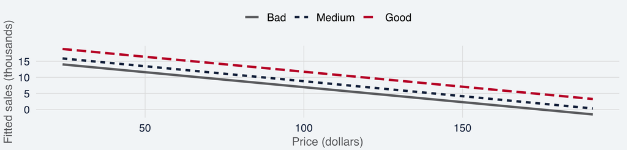

## Nested models:

- How does the coefficient you care about or the predictive capacity of the model change once you add variables?

| Model | Price | R² | RSE |
| --- | --- | --- | --- |
| Sales ~ Price | -0.053 | 0.198 | 2.53 |
| + CompPrice + Income | -0.087 | 0.381 | 2.23 |
| + Advertising | -0.091 | 0.475 | 2.06 |
| + ShelveLoc | -0.093 | 0.803 | 1.26 |

- When a predictor is added: does the coefficient you care about **change**? Does $R^2$ rise, and RSE fall, enough to matter?
- $R^2$ always rises (weakly) when a predictor is added. That is not, by itself, a reason to include it.

## Overall $F$: are all slopes zero?

- The overall $F$ asks whether **at least one** slope is not zero.

$$H_0{:}\ \beta_1 = \beta_2 = \cdots = \beta_p = 0$$

- That is not the same question as “is the $t$ on Price large?” If you look at many $t$ statistics and keep the stars, some of those stars will be accidents.

```r
summary(m3)$fstatistic
```

```
    value     numdf     dendf
 89.20977   4.00000 395.00000
```

## Nested $F$: adding CompPrice and Income

- Price is already in the model. Do CompPrice and Income belong as well?
- A nested $F$ compares a **small** model to a **larger** one that contains it.
  - Null: the extra coefficients are all zero.

```r
anova(m1, m2)
```

```
Analysis of Variance Table

Model 1: Sales ~ Price
Model 2: Sales ~ Price + CompPrice + Income
  Res.Df    RSS Df Sum of Sq      F    Pr(>F)
1    398 2552.2
2    396 1971.3  2     580.9 58.345 < 2.2e-16 ***
---
Signif. codes:  0 '***' 0.001 '**' 0.01 '*' 0.05 '.' 0.1 ' ' 1
```

## Confidence interval versus prediction interval

Headquarters has use the model to get a prediction for sales number at a given price. How sure should they be about this prediction? and sure about *what*?

Two different questions.

- **Mean at this price.** What is typical sales for stores with a price of $120? That is a **confidence interval** for $f(x)$.
- **This store at this price.** Store 1 lists at $120. Where will *its* sales fall, including potential errors in the prediction? That is a **prediction interval**.

Same $\hat Y$? How are they different?

## What is extra in the prediction interval?

- For the simple line, at a price $x_0$, the standard error for a given prediction can be described by:

$$\mathrm{SE}(\hat\mu(x_0))^2 = \hat\sigma^2\left(\frac{1}{n}+\frac{(x_0-\bar x)^2}{\sum_i(x_i-\bar x)^2}\right).$$

Confidence interval

$$\hat y(x_0) \pm t^{*}\,\mathrm{SE}(\hat\mu(x_0))$$

Uncertainty in the fitted mean only.

Prediction interval

$$\hat y(x_0) \pm t^{*}\sqrt{\mathrm{SE}(\hat\mu(x_0))^2 + \hat\sigma^2}$$

That, plus $\hat\sigma^2$: leftover of a new store.

- The extra $\hat\sigma^2$ is why the prediction interval is wider. A new store still has $\varepsilon$.

## Which band do we read?

- Inner band: mean sales at that price.
- Outer band: one store at that price, including $\varepsilon$.

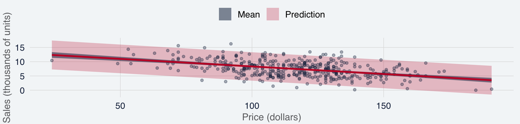

- **Segment mean** (typical sales at this price): inner band.
- **One new store** next quarter: outer band.

## Store 1: two intervals around the same $\hat Y$

```r
nd <- stores[1, ]
predict(m3, newdata = nd, interval = "confidence")
```

```
       fit      lwr      upr
1 9.007221 8.693118 9.321323
```

```r
predict(m3, newdata = nd, interval = "prediction")
```

```
       fit      lwr      upr
1 9.007221 4.950334 13.06411
```

- Same center ($\hat Y \approx 9.01$), but the prediction interval is wider.
- Why? The extra $\hat\sigma^2$ on the last slide?
- When to use each one:
  - **Use the CI** for the mean of stores with this mix.
  - **Use the PI** if finance is asking about a specific store next quarter.

## What’s the distribution of the residuals?

- Those 95% intervals assume residuals are roughly symmetric, piled near zero. Is that true on this fit?

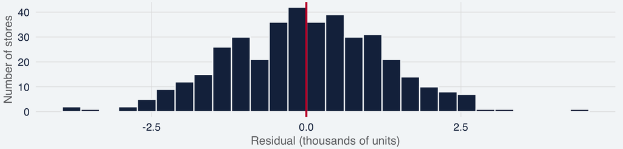

- Leftover $e_i = y_i - \hat y_i$. A mound around zero supports the coverage of those intervals.
- It does **not** tell us to raise the price.

## Extensions and problems with regression

Interactions, assumptions, and potential problems (ISLR 87-103)

## Outline

1. **Interactions**: What happens when the association of one $X$ with sales depends on another $X$. Scenarios:
   - Continuous $\times$ continuous
   - Continuous $\times$ categorical
   - Categorical $\times$ categorical
2. **Assumptions and potential problems**
   - Nonlinearity of $E(Y\mid X)$
   - Correlated residuals
   - Non-constant residual variance
   - Outliers
   - High-leverage observations
   - Collinearity

## Three kinds of interaction

- What happens when the effect of x on sales is conditioned on another variable?
  - **Continuous $\times$ continuous.** Does local advertising associate more with sales in richer neighborhoods?
  - **Continuous $\times$ categorical.** Does the Price slope differ on Bad vs Good shelves?
  - **Categorical $\times$ categorical.** Does a Good shelf associate with extra sales more intensively in US stores?

## Does advertising pay more in richer neighborhoods?

Ads slope at a given income: $\beta_1 + \beta_3\,\mathrm{Income}$.

$$\mathrm{Sales} = \beta_0 + \beta_1\mathrm{Advertising} + \beta_2\mathrm{Income} + \beta_3(\mathrm{Advertising}\times\mathrm{Income}) + \cdots + \varepsilon.$$

```r
m_axinc <- lm(Sales ~ Advertising * Income + Price + CompPrice + ShelveLoc, data = stores)
```

| Term | Estimate | Std. Error | t | p-value |
| --- | --- | --- | --- | --- |
| Advertising | 0.0413 | 0.0255 | 1.62 | 0.10563 |
| Income | 0.0090 | 0.0032 | 2.83 | 0.00497 |
| Advertising:Income | 0.0011 | 0.0003 | 3.16 | 0.00168 |

Note: Price, CompPrice, and shelf are still in the model. Omitted from the table.

## How do we interpret Advertising $\times$ Income?

- The interaction `Advertising:Income` is 0.0011.
- Advertising and Income are in thousands of dollars.
- **What this means**?
  - A one-unit increase in Income ($1,000 of community income) raises the Advertising slope by 0.0011 thousand seats per extra $1,000 of ads.

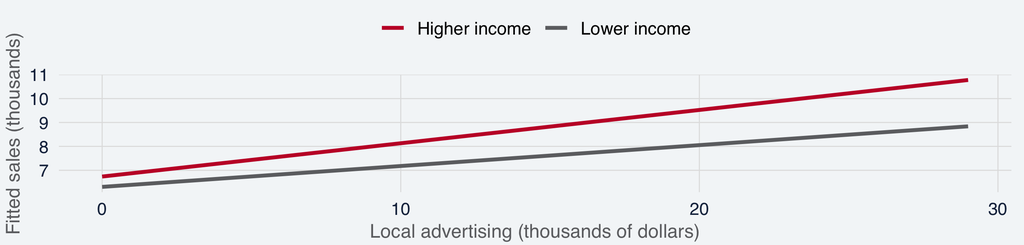

## What Advertising $\times$ Income means for two stores

- We evaluate at the **25th and 75th percentiles of Income** so the interaction becomes two Advertising slopes: a lower-income store and a higher-income store.
  - At the 25th percentile of Income, an extra $1,000 of advertising is associated with about 87 extra seats.
  - At the 75th percentile, the same extra $1,000 of ads is associated with about 139 extra seats.
- **Implication:** The ads association is larger where income is higher.
- **How this can be used to better allocate ads budget?**

## Does the effect of prices on sales depend on the shelf?

- $\beta_1$ as the Price slope when the shelf is Bad.
- $\beta_1+\beta_{\mathrm{P,Good}}$ as that slope when the shelf is Good.

$$\begin{aligned}
E(\mathrm{Sales}\mid \ldots)
&= \beta_0 + \beta_1\mathrm{Price} + \beta_{\mathrm{Med}}M + \beta_{\mathrm{Good}}G \\
&\quad + \beta_{P,M}(\mathrm{Price}\times M) + \beta_{P,G}(\mathrm{Price}\times G)+\cdots.
\end{aligned}$$

```r
m_pxsh <- lm(Sales ~ Price * ShelveLoc + CompPrice + Income + Advertising, data = stores)
```

| Term | Estimate | Std. Error | t | p-value |
| --- | --- | --- | --- | --- |
| Price | -0.0893 | 0.0057 | -15.57 | < 0.001 |
| ShelveLocMedium | 2.4732 | 0.7749 | 3.19 | 0.00153 |
| ShelveLocGood | 5.3538 | 0.9204 | 5.82 | < 0.001 |
| Price:ShelveLocMedium | -0.0054 | 0.0066 | -0.82 | 0.41205 |
| Price:ShelveLocGood | -0.0048 | 0.0078 | -0.62 | 0.53249 |

## How do we interpret Price $\times$ shelf?

- **What this means?**
  - Are sales more responsive to prices depending on the shelf?
- The effect of `Price` alone is -0.0893.
  - A one-dollar higher list price is associated with -0.089 thousand fewer seats (about 89 seats).

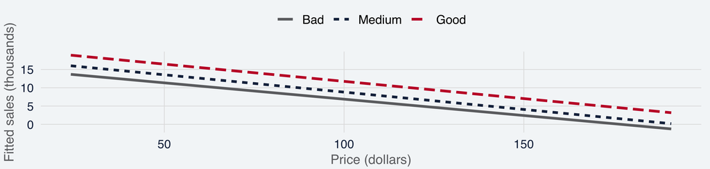

## What Price $\times$ shelf means

- The interaction `Price:ShelveLocGood` is -0.0048 ($t \approx$ -0.62).
  - Moving from Bad to Good shelf changes the Price effect on sales by -0.0048 thousand seats per dollar. A modest effect.
- Bad-shelf Price slope: -0.089, about 89 fewer seats per extra dollar of list price.
- Good-shelf Price slope: -0.094, about 94 fewer seats per extra dollar.
- Price sensitivity is about the same on good and bad shelves.
  - A good shelf mainly raises the **level** of sales, but doesn’t affect the effect of prices on sales.

## Does a Good shelf mean more in a US store?

- $\beta_{\mathrm{Good}}$ is the Good-versus-Bad sales gap when US = No.
- $\beta_{\mathrm{Good}}+\beta_{\mathrm{G,US}}$ is that gap when the store is in the US.

$$E(\mathrm{Sales}\mid \ldots)
= \beta_0 + \beta_{\mathrm{Good}}G + \beta_{\mathrm{US}}U + \beta_{\mathrm{G,US}}(G\times U)+\cdots.$$

```r
m_shus <- lm(Sales ~ ShelveLoc * US + Price + CompPrice + Income + Advertising, data = stores)
```

| Term | Estimate | Std. Error | t | p-value |
| --- | --- | --- | --- | --- |
| ShelveLocMedium | 1.5850 | 0.2556 | 6.20 | < 0.001 |
| ShelveLocGood | 4.1979 | 0.3357 | 12.50 | < 0.001 |
| USYes | -0.6201 | 0.2910 | -2.13 | 0.0337 |
| ShelveLocMedium:USYes | 0.3969 | 0.3208 | 1.24 | 0.2168 |
| ShelveLocGood:USYes | 0.8823 | 0.4057 | 2.17 | 0.0303 |

## How do we interpret shelf $\times$ US?

- **What this means?**
  - `ShelveLocGood` is 4.20
  - In a **non-US** store, a Good shelf is associated with 4.20 thousand extra seats relative to a Bad shelf, holding Price, CompPrice, Income, and Advertising fixed.

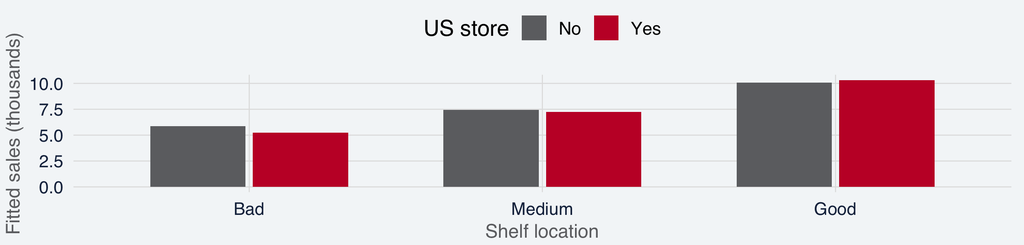

## What shelf $\times$ US means

- The interaction `ShelveLocGood:USYes` is 0.88. That is how much **larger** the Good-versus-Bad gap is when the store is in the US.
  - In a non-US store, a good shelf is associated with 4.20 thousand extra seats relative to a bad shelf.
  - In a US store the same comparison is 5.08 thousand seats.
- A good shelf is associated with a larger sales gap **inside** the US than outside. Implications?

## What are we assuming when we run regressions?

1. **Linearity of the conditional mean**
   - **Meaning:** $E(\mathrm{Sales}\mid X)$ is a plane in Price, advertising, income, and shelf location.
   - **When it is violated.** Sales flatten at high prices.
   - If ignored A $10 price increase is treated as the same sales gap at every price.
2. **Uncorrelated errors**
   - **Meaning.** The error in store $i$ does not track the error in store $j$.
   - **When it is violated.** Nearby stores share a demand shock, or the same store is observed week after week.
   - If ignored SEs and $t$-statistics look too tight, so statistical significance can be an accident.

## What else are we assuming?

3. **Constant error variance**
   - **Meaning.** The error spread is the same at every predicted sales level.
   - **When it is violated.** High-volume stores miss by more than low-volume stores.
   - If ignored, A 95% interval for a busy store may be too tight.
4. **Normal (or at least mound-shaped) errors**
   - *Needed for the coverage of the CI and PI we computed.*
   - **Meaning.** Residuals pile near zero, not in a long one-sided tail.
   - **When it is violated.** A long right tail of large positive misses.
   - If ignored, The 95% CI and PI no longer cover about 95% of the time, especially for a single new store.

## Influential points and collinearity

5. **No influential points**
   - Meaning: $\hat\beta$ is not determine by one or a have influential observations.
   - Violation:
     - One store with an unusual price pulls the Price slope.
   - If ignored:
     - Making decisions about sales sensitivity to prices based on just one data point!
6. **No collinearity**
   - Meaning: the $X$s are not almost “perfectly collinear”, so each $\hat\beta$ can be separated.
   - Violation:
     - Price and CompPrice move as almost one variable.
     - Imagine you can express Price as linear function of CompPrice. Price = 2*CompPrice
   - If ignored:
     - own-price and competitor coefficients are unstable, therefore you can not separate the effect of your own change in prices, from the effect of your competitor.

## Nonlinearity: is a straight line enough?

- If $E(Y\mid X)$ curves, $\hat\beta_{\mathrm{Price}}$ is an average slope that no store actually has. Would you still use it to price?

$$E(Y\mid X)=\beta_0+\beta_1 X+\cdots.$$

- A curve in the residual versus $\hat y$ means that we have misspecified our equation. How to check?
- Add $\mathrm{Price}^2$ and compared top the model without it.

```r
m_quad <- lm(Sales ~ Price + I(Price^2) + CompPrice + Income + Advertising + ShelveLoc, data = stores)
anova(m4, m_quad)
```

```
Analysis of Variance Table

Model 1: Sales ~ Price + CompPrice + Income + Advertising + ShelveLoc
Model 2: Sales ~ Price + I(Price^2) + CompPrice + Income + Advertising +
    ShelveLoc
  Res.Df    RSS Df Sum of Sq      F Pr(>F)
1    393 626.51
2    392 624.59  1    1.9167 1.2029 0.2734
```

- The nested $F$ for adding $\mathrm{Price}^2$ has $p \approx 0.27$. Linear model seems ok!

## Residual versus fitted: do we see a curve?

- If linearity of the conditional mean holds, residuals should sit in a band around zero, with no U-shape.
- A curve here would mean one Price slope is the wrong object for pricing.

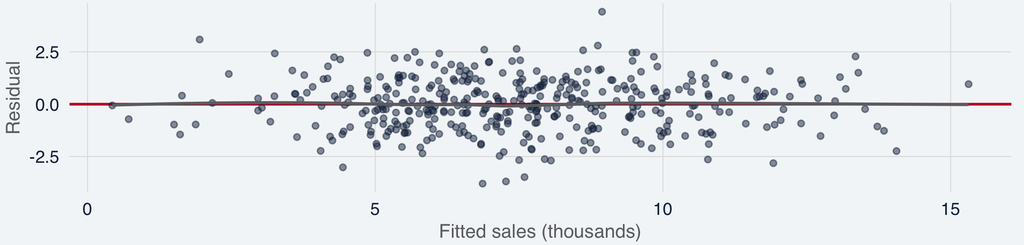

## Uncorrelated errors: can we check that here?

- The assumption is uncorrelated errors: $\mathrm{Cov}(\varepsilon_i,\varepsilon_j)=0$ for $i\neq j$.
  - If it fails, SE and $t$ are too optimistic. Can we see that in this file?

```r
acf(resid(m4), plot = FALSE)$acf[2]
```

```
[1] -0.08063718
```

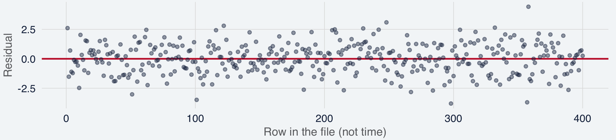

## Constant error variance: do we have it?

- Usual SE and $t$ assume constant error variance: $\mathrm{Var}(\varepsilon_i\mid X)=\sigma^2$.
  - If high-sales stores miss by more, a 95% interval for a busy store is too tight. Do they?
- A rising smooth in $|e|$ versus $\hat y$ is non-constant variance (heteroscedasticity).
  - Correlation of fitted Sales with the absolute residual is about 0.02. Implications?

```r
cor(fitted(m4), abs(resid(m4)))
```

```
[1] 0.01808987
```

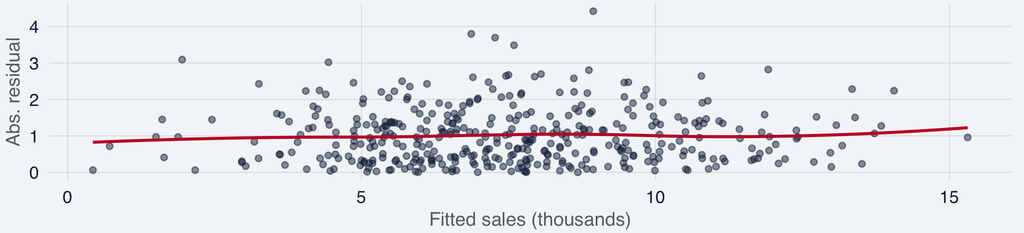

## Outliers: is one store driving the results?

- A store with a huge influence (residual) can pull $\hat\beta$ and the RSE.
  - If no accounted for, you can make a decision about price driven by the influence of just one store
- An outlier is a large residual $e_i=y_i-\hat y_i$.
- Useful concept: studentized residual $e_i\big/\big(\hat\sigma_{(i)}\sqrt{1-h_{ii}}\big)$. If $|r_i|>3$, that could considered an outlier!

```r
sum(abs(rstudent(m4)) > 3)
```

```
[1] 3
```

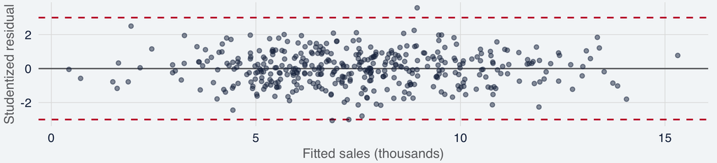

## High-leverage data points (stores): unusual $X$

- A store with a very unusual price can affect the slope.
- Leverage $h_{ii}$ measures how unusual that store’s $X$ row is (its Price, ads, etc). A conventional flag is $h_{ii} > 2p/n$. The number below is the share of stores above that flag. Those stores can move $\hat\beta$ even when the residual is not huge.

```r
p_m4 <- length(coef(m4))
mean(hatvalues(m4) > 2 * p_m4 / nobs(m4))
```

```
[1] 0.0225
```

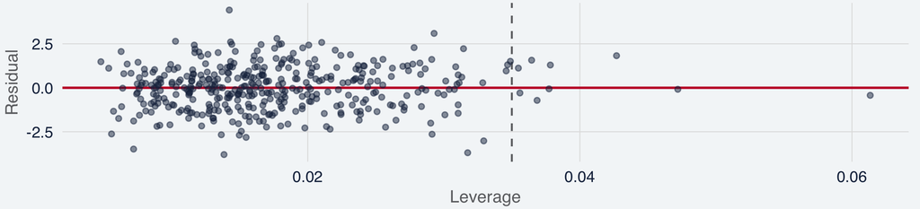

## Collinearity: Price and CompPrice

- Own price and the competitor’s price move together (0.58). Does that affect our capacity to interpret Own price coefficient and make decesions with it?
- One way to evaluate the relevance of collinearity is calculating Variance Inflation Factors (VIF).
  $$\mathrm{VIF}_j = \frac{1}{1-R_j^2},\qquad R_j^2\text{ from }X_j\text{ on the other }X.$$

```r
r2_price <- summary(lm(Price ~ CompPrice + Income + Advertising + ShelveLoc, data = stores))$r.squared
1 / (1 - r2_price)
```

```
[1] 1.530016
```

## Price versus CompPrice

- There is correlation, but not so high as to invalidate the use of the coefficients for those variables for decision making.

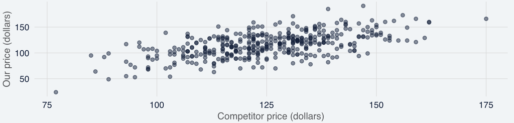

## Another important considerations

- **Associations are not causal effects**
  - There was not experiment. Prices, ads, and shelves were not randomly assigned.
  - $\hat\beta_{\mathrm{Price}}$ is not “the effect of cutting the price.”
- **Prediction outside our sample**. Every $R^2$ and RSE here uses the same 400 rows used to fit.
  - Model could be very good at predicting using the same sample, but may not have good accuracy out of sample (overfitting).
- **Not immune to collinearity.** Price and CompPrice are correlated. If they were nearly the same series, the individual coefficients would be unstable even if fitted values remained usable.

## Summary

What you should be able to do after these two sessions.

## What you should be able to do

- Identify the use of a regression: description, explanation, prediction, or causal inference when the design allows it.
- Write the simple and multiple linear models, including the error term $\varepsilon$.
- Estimate $\hat\beta$ in R and interpret the Estimate, standard error, $t$-statistic, and $p$-value.
- Distinguish statistical significance from economic significance, and judge whether a coefficient is large enough to matter for a decision.
- Interpret goodness of fit: residual standard error (RSE) in the units of $Y$, and $R^2$ as the share of variance explained.
- Interpret coefficients on categorical predictors, including what the omitted baseline category means.
- Explain the difference between a confidence interval and a prediction interval, and which question each one answers.
- Interpret interaction coefficients: continuous $\times$ continuous, continuous $\times$ categorical, and categorical $\times$ categorical.
- Diagnose and test the standard linear-regression problems: nonlinear conditional mean, correlated errors, nonconstant variance, outliers, high-leverage points, and collinearity.

## Quiz 1 is at the end of class

Paper, about 10–15 minutes, closed notes. It covers Wednesday **and** today: simple regression and multiple regression.

Then we stop. Wednesday is the first lab, a different file. Homework 1 goes out that day.

If R or RStudio is still not working, see me after class today.

## Before Wednesday

First lab in person. Please bring a laptop. Homework 1 goes out Wednesday (due 9 September).

After today

I will share a short problem on the lab file, plus starter code. Please make sure you look at those before Wednesday.

Setup

Please make sure R and RStudio run on the course website Setup page, so we do not spend the lab on installation.

Quiz 1

At the end of *this* class. Paper, 10–15 minutes, closed notes. Wednesday and today.